# Kallisto bustools Processing

This notebook is an example of processing a kallsto|bustools run as implemented in the `run-kallisto.nf` workflow.

```r
library(magrittr)
library(ggplot2)
library(SingleCellExperiment)
```

First we will download a data set to work with from S3. This set was quantified as part of a benchmarking set. This step assumes that `awscli` is installed (which it is if you use the `scpca-r` docker image) and that you have already set up credentials.

```r
data_dir <- file.path("data", "kallisto", "834")
dir.create(data_dir, recursive = TRUE, showWarnings = FALSE)
quant_s3 <- "s3://nextflow-ccdl-results/scpca-benchmark/quants/kallisto/834-kallisto_cdna"
mito_s3 <- "s3://nextflow-ccdl-data/reference/homo_sapiens/ensembl-100/annotation/Homo_sapiens.ensembl.100.mitogenes.txt"
mito_file <- file.path("data", "Homo_sapiens.ensembl.100.mitogenes.txt")
```

### Sync S3 files

```r
sync_call <- paste("aws s3 sync", quant_s3, data_dir, "--exclude 'bus/*'")
system(sync_call, ignore.stdout = TRUE)

# get the mitochondrial gene set
cp_call <- paste("aws s3 cp", mito_s3, mito_file)
system(cp_call)
```

```
Completed 592 Bytes/592 Bytes (5.6 KiB/s) with 1 file(s) remaining
download: s3://nextflow-ccdl-data/reference/homo_sapiens/ensembl-100/annotation/Homo_sapiens.ensembl.100.mitogenes.txt to data/Homo_sapiens.ensembl.100.mitogenes.txt
```

## Read counts matrix

```r
file_base <- file.path(data_dir, "counts", "gene_count")

counts <- Matrix::readMM(paste0(file_base, ".mtx")) %>%
  # compress and transpose to genes in rows x cells in columns
  t() %>%
  as("dgCMatrix")
# add annotation info
dimnames(counts) <- list(readLines(paste0(file_base, ".genes.txt")),
                         readLines(paste0(file_base, ".barcodes.txt")))
```

## Identifying cells with droplets

### Cellranger default method first.

Based on library size, capturing cells with at least 10% of the UMI counts of the upper 99th percentile.

```r
system.time(drops <- DropletUtils::defaultDrops(counts))
```

```
   user  system elapsed
  0.116   0.003   0.119
```

```r
sum(drops)
```

```
[1] 1508
```

```r
min(colSums(counts[,drops]))
```

```
[1] 4345
```

### Knee plot method

Find the knee, keep the cells above that rank.

```r
system.time(rank_df <- DropletUtils::barcodeRanks(counts))
```

```
   user  system elapsed
  0.177   0.012   0.189
```

```r
knee <- metadata(rank_df)$knee
inflection <- metadata(rank_df)$inflection

sum(rank_df$total >= knee)
```

```
[1] 1240
```

```r
min(colSums(counts[,which(rank_df$total >= knee)]))
```

```
[1] 5333
```

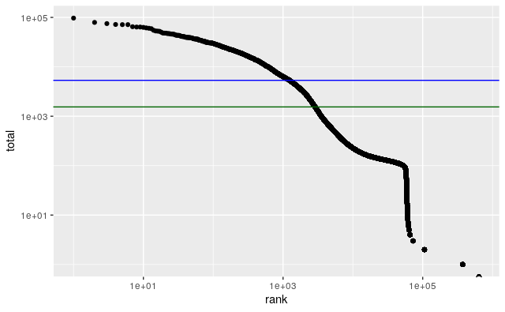

```r
ggplot(as.data.frame(rank_df), aes(x = rank, y = total)) +
  geom_point() +
  geom_hline(yintercept = knee, color = "blue") +
  geom_hline(yintercept = inflection, color = "darkgreen") +
  scale_x_log10() +
  scale_y_log10()
```

### EmptyDrops method

Fancy method: difference from ambient RNA distribution. (v. slow so may not be worth pursuing in this context, but could be added to a workflow?)

```r
system.time(drop_df <- DropletUtils::emptyDrops(counts))
```

```
   user  system elapsed
 71.713   0.306  72.239
```

```r
is.cell <- drop_df$FDR <= 0.01
sum(is.cell, na.rm=TRUE)
```

```
[1] 23520
```

This method also keeps many more “cells”, which may be net negative for downstream processing as well, but may also be worth pursuing for some kinds of analysis.

## Make SCE object

For now, we will proceed with the knee method to define cells.

```r
cells <- which(rank_df$total >= knee)
sce <- SingleCellExperiment(list(counts = counts[ , cells]))
```

That results in a much more reasonably sized object, one we can work with as usual with SCE objects.

## Simple QC plots

```r
mito_genes <- readLines(mito_file)

sce <- scater::addPerCellQC(
  sce,
  subsets = list(mito = mito_genes[mito_genes %in% rownames(sce)])
) %>%
  scater::addPerFeatureQC()
```

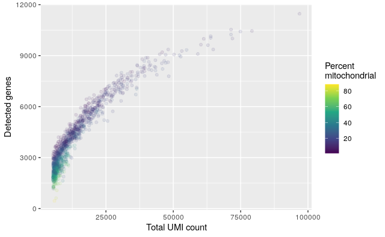

```r
ggplot(as.data.frame(colData(sce)),
       aes(x = sum, y = detected, color = subsets_mito_percent)) +
  geom_point(alpha = 0.1) +
  labs(x = "Total UMI count",
       y = "Detected genes",
       color = "Percent\nmitochondrial") +
  scale_color_viridis_c()
```

### EmptyDrops QC plots

Out of curiosity, what do the EmptyDrops results look like?

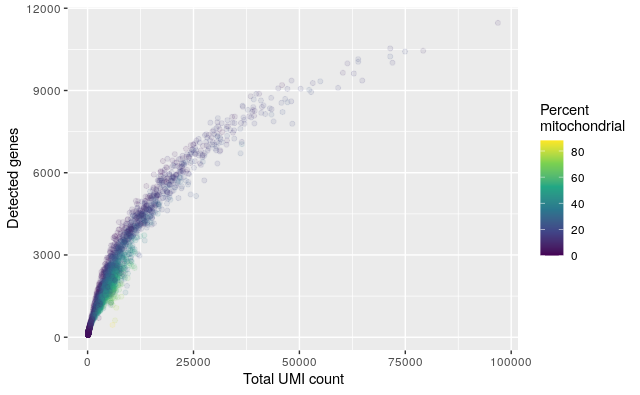

```r
sce_ed <- SingleCellExperiment(list(counts = counts[ , which(is.cell)]))

sce_ed <- scater::addPerCellQC(
  sce_ed,
  subsets = list(mito = mito_genes[mito_genes %in% rownames(sce_ed)])
) %>%
  scater::addPerFeatureQC()

ggplot(as.data.frame(colData(sce_ed)),
       aes(x = sum, y = detected, color = subsets_mito_percent)) +
  geom_point(alpha = 0.1) +
  labs(x = "Total UMI count",
       y = "Detected genes",
       color = "Percent\nmitochondrial") +
  scale_color_viridis_c()
```

## Sequential filtering

What happens if we look at the knee plot after EmptyDrops excludes ambient expression drops?

```r
rank_df <- DropletUtils::barcodeRanks(counts(sce_ed))
knee <- metadata(rank_df)$knee
inflection <- metadata(rank_df)$inflection

sum(rank_df$total >= knee)
```

```
[1] 1874
```

```r
min(colSums(counts(sce_ed)[,which(rank_df$total >= knee)]))
```

```
[1] 3009
```

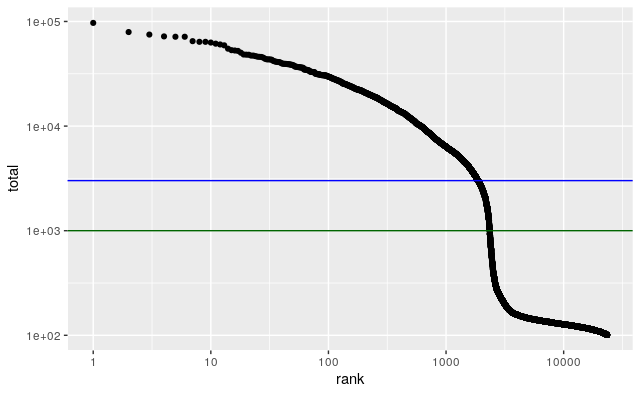

```r
ggplot(as.data.frame(rank_df), aes(x = rank, y = total)) +
  geom_point() +
  geom_hline(yintercept = knee, color = "blue") +
  geom_hline(yintercept = inflection, color = "darkgreen") +
  scale_x_log10() +
  scale_y_log10()
```